# Bank Churn Prediction - Connie Xavier

### Model 3

```python
backend.clear_session()
np.random.seed(1)
random.seed(1)
tf.random.set_seed(1)
```

```python
model3 = Sequential()
# Adding the hidden and output layers
model3.add(
    Dense(
        32,
        activation="relu",
        kernel_initializer="he_uniform",
        input_dim=X_train.shape[1],
    )
)
model3.add(Dropout(0.2))
model3.add(Dense(16, activation="relu", kernel_initializer="he_uniform"))
model3.add(Dropout(0.2))
model3.add(Dense(8, activation="relu", kernel_initializer="he_uniform"))
model3.add(Dropout(0.2))
model3.add(Dense(1, activation="sigmoid"))
# Compiling the ANN with Adam optimizer and binary cross entropy loss function
optimizer = tf.keras.optimizers.Adam(0.001)
model3.compile(loss="binary_crossentropy", optimizer=optimizer, metrics=["accuracy"])
# Defining Early stopping
es_cb = callbacks.EarlyStopping(monitor="val_loss", min_delta=0.0001, patience=8)
```

```python
model3.summary()
```

```
Model: "sequential"
_________________________________________________________________
 Layer (type)                Output Shape              Param #
=================================================================
 dense (Dense)               (None, 32)                384

 dropout (Dropout)           (None, 32)                0

 dense_1 (Dense)             (None, 16)                528

 dropout_1 (Dropout)         (None, 16)                0

 dense_2 (Dense)             (None, 8)                 136

 dropout_2 (Dropout)         (None, 8)                 0

 dense_3 (Dense)             (None, 1)                 9

=================================================================
Total params: 1,057
Trainable params: 1,057
Non-trainable params: 0
_________________________________________________________________
```

```python
# Fitting the model on train and validation with 100 epochs
history3 = model3.fit(
    X_train,
    y_train,
    batch_size=32,
    validation_data=(X_val, y_val),
    epochs=100,
    callbacks=es_cb,
)
```

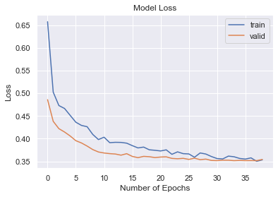

```python
# Capturing learning history per epoch
hist = pd.DataFrame(history3.history)
hist["epoch"] = history3.epoch

# Plotting accuracy at different epochs
plt.plot(hist["loss"])
plt.plot(hist["val_loss"])
plt.legend(("train", "valid"), loc=0)
plt.xlabel("Number of Epochs")
plt.ylabel("Loss")
plt.title("Model Loss")

# Printing results
results = model3.evaluate(X_val, y_val)
```

- Dropout and EarlyStopping has really helped in reduce overfitting.

```
Best Threshold=0.204219, G-Mean=0.797
```

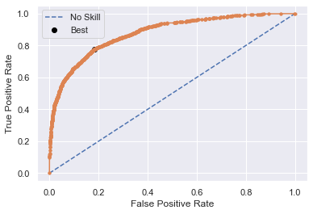

```python
# find threshold using ROC-AUC curve.
# predict probabilities
yhat1 = model3.predict(X_train)
# keep probabilities for the positive outcome only
yhat1 = yhat1[:, 0]
# calculate roc curves
fpr, tpr, thresholds1 = roc_curve(y_train, yhat1)
# calculate the g-mean for each threshold
# g-mean is a metric for imbalanced classification that, if optimized, will seek a balance between the sensitivity and the specificity.
gmeans1 = np.sqrt(tpr * (1 - fpr))
# locate the index of the largest g-mean
ix = np.argmax(gmeans1)
print("Best Threshold=%f, G-Mean=%.3f" % (thresholds1[ix], gmeans1[ix]))
# plot the roc curve for the model
pyplot.plot([0, 1], [0, 1], linestyle="--", label="No Skill")
pyplot.plot(fpr, tpr, marker=".")
pyplot.scatter(fpr[ix], tpr[ix], marker="o", color="black", label="Best")
# axis labels
pyplot.xlabel("False Positive Rate")
pyplot.ylabel("True Positive Rate")
pyplot.legend()
# show the plot
pyplot.show()
```

```
              precision    recall  f1-score   support

           0       0.92      0.82      0.87      1592
           1       0.51      0.73      0.60       408

    accuracy                           0.80      2000
   macro avg       0.72      0.78      0.73      2000
weighted avg       0.84      0.80      0.81      2000
```

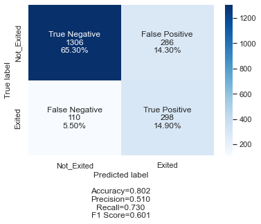

```python
# Predicting the results using best as a threshold
y_pred_e3 = model3.predict(X_val)
y_pred_e3 = y_pred_e3 > thresholds1[ix]
# Calculating the confusion matrix
cm3 = confusion_matrix(y_val, y_pred_e3)
cm3_r = stats(cm3)
labels = ["True Negative", "False Positive", "False Negative", "True Positive"]
categories = ["Not_Exited", "Exited"]
make_confusion_matrix(cm3, group_names=labels, categories=categories, cmap="Blues")
# Accuracy as per the classification report
cr3 = metrics.classification_report(y_val, y_pred_e3)
print(cr3)
```

- Accuracy and recall have now improved from the previous model.
- We will use GridSearch to see if we tune the hyperparameters.

### Model 4

#### **Grid Search CV**

Some important hyperparameters to look out for while optimizing neural networks are:

- Type of Architecture
- Number of Layers
- Number of Neurons in a layer
- Regularization hyperparameters
- Learning Rate
- Type of Optimizer
- Dropout Rate

We will vary the dropout rate, learning rate, and batch size.

```python
backend.clear_session()
# Fixing the seed for random number generators so that we can ensure we receive the same output everytime
np.random.seed(1)
random.seed(1)
tf.random.set_seed(1)
```

```python
def create_model_4(lr, dropout, batch_size, units1=32, units2=16, units3=8):
    np.random.seed(1337)
    model = Sequential()
    model.add(
        Dense(
            units1,
            activation="relu",
            input_dim=X_train.shape[1],
            kernel_initializer="he_uniform",
        )
    )
    model.add(Dropout(dropout))
    model.add(Dense(units2, activation="relu", kernel_initializer="he_uniform"))
    model.add(Dropout(dropout))
    model.add(Dense(units3, activation="relu", kernel_initializer="he_uniform"))
    model.add(Dropout(dropout))
    model.add(Dense(1, activation="sigmoid"))

    # compile model
    optimizer = tf.keras.optimizers.Adam(learning_rate=lr)
    model.compile(optimizer=optimizer, loss="binary_crossentropy", metrics=["accuracy"])
    return model
```

```python
keras_estimator = KerasClassifier(build_fn=create_model_4, verbose=1)
# define the grid search parameters
param_grid = {
    "batch_size": [32, 64, 128],
    "lr": [0.001, 0.01, 0.1],
    "dropout": [0.1, 0.2, 0.5],
}

kfold_splits = 3
grid = GridSearchCV(
    estimator=keras_estimator,
    verbose=1,
    cv=kfold_splits,
    param_grid=param_grid,
    n_jobs=-1,
)
```

```python
# fitting Grid model
grid_result = grid.fit(X_train, y_train, validation_data=(X_val, y_val), verbose=1)

# Summarize results
print("Best: %f using %s" % (grid_result.best_score_, grid_result.best_params_))
means = grid_result.cv_results_["mean_test_score"]
stds = grid_result.cv_results_["std_test_score"]
params = grid_result.cv_results_["params"]
```

```
Fitting 3 folds for each of 27 candidates, totalling 81 fits
Best: 0.828000 using {'batch_size': 32, 'dropout': 0.1, 'lr': 0.01}
```

```python
model4 = create_model_4(
    batch_size=grid_result.best_params_["batch_size"],
    lr=grid_result.best_params_["lr"],
    dropout=grid_result.best_params_["dropout"],
)

model4.summary()
```

```
Model: "sequential_1"
_________________________________________________________________
 Layer (type)                Output Shape              Param #
=================================================================
 dense_4 (Dense)             (None, 32)                384

 dropout_3 (Dropout)         (None, 32)                0

 dense_5 (Dense)             (None, 16)                528

 dropout_4 (Dropout)         (None, 16)                0

 dense_6 (Dense)             (None, 8)                 136

 dropout_5 (Dropout)         (None, 8)                 0

 dense_7 (Dense)             (None, 1)                 9

=================================================================
Total params: 1,057
Trainable params: 1,057
Non-trainable params: 0
_________________________________________________________________
```

```python
optimizer = tf.keras.optimizers.Adam(grid_result.best_params_["lr"])
model4.compile(loss="binary_crossentropy", optimizer=optimizer, metrics=["accuracy"])
# fit the model
history4 = model4.fit(
    X_train,
    y_train,
    epochs=50,
    batch_size=grid_result.best_params_["batch_size"],
    verbose=1,
    validation_data=(X_val, y_val),
    callbacks=es_cb,
)
```

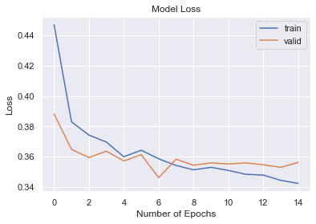

```python
# Capturing learning history per epoch
hist = pd.DataFrame(history4.history)
hist["epoch"] = history4.epoch

# Plotting accuracy at different epochs
plt.plot(hist["loss"])
plt.plot(hist["val_loss"])
plt.legend(("train", "valid"), loc=0)
plt.xlabel("Number of Epochs")
plt.ylabel("Loss")
plt.title("Model Loss")

# Printing results
results = model4.evaluate(X_val, y_val)
```

- There is more noise in this model than the previous one, and starts to overfit to the training data.

```
Best Threshold=0.208702, G-Mean=0.803
```

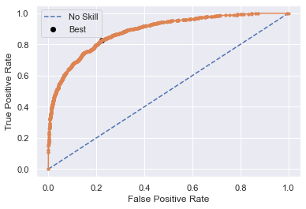

```python
# find threshold using ROC-AUC curve.
# predict probabilities
yhat1 = model4.predict(X_train)
# keep probabilities for the positive outcome only
yhat1 = yhat1[:, 0]
# calculate roc curves
fpr, tpr, thresholds1 = roc_curve(y_train, yhat1)
# calculate the g-mean for each threshold
# g-mean is a metric for imbalanced classification that, if optimized, will seek a balance between the sensitivity and the specificity.
gmeans1 = np.sqrt(tpr * (1 - fpr))
# locate the index of the largest g-mean
ix = np.argmax(gmeans1)
print("Best Threshold=%f, G-Mean=%.3f" % (thresholds1[ix], gmeans1[ix]))
# plot the roc curve for the model
pyplot.plot([0, 1], [0, 1], linestyle="--", label="No Skill")
pyplot.plot(fpr, tpr, marker=".")
pyplot.scatter(fpr[ix], tpr[ix], marker="o", color="black", label="Best")
# axis labels
pyplot.xlabel("False Positive Rate")
pyplot.ylabel("True Positive Rate")
pyplot.legend()
# show the plot
pyplot.show()
```

```
              precision    recall  f1-score   support

           0       0.93      0.78      0.85      1592
           1       0.47      0.77      0.58       408

    accuracy                           0.78      2000
   macro avg       0.70      0.77      0.71      2000
weighted avg       0.83      0.78      0.79      2000
```

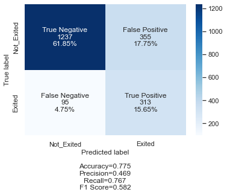

```python
# Predicting the results using best as a threshold
y_pred_e4 = model4.predict(X_val)
y_pred_e4 = y_pred_e4 > thresholds1[ix]
# Calculating the confusion matrix
cm4 = confusion_matrix(y_val, y_pred_e4)
cm4_r = stats(cm4)
labels = ["True Negative", "False Positive", "False Negative", "True Positive"]
categories = ["Not_Exited", "Exited"]
make_confusion_matrix(cm4, group_names=labels, categories=categories, cmap="Blues")

# Accuracy as per the classification report
cr4 = metrics.classification_report(y_val, y_pred_e4)
print(cr4)
```

- Recall is the highest so far.
- We will now try finding the best parameters using Keras Tuner and Random Search.